# Hybrid & Technical Strategy Backtest, Optimizations, and Comparision.

Ji

2025-04-06

## 1. Load data,also cleaning

```r
symbols <- c("NVDA", "SOXL", "XOM", "CLS.TO")
standard_cols <- as.character(c("Date", symbols))

library(readr)
library(openxlsx)

p_risk <- read_csv("daily_prisk_signals.csv")
p_ma_3_12 <- read_csv("final_PMA_3month&12month.csv")  # MA3/12
p_ma_12_36 <- read_csv("final_PMA_12month&36month.csv")  # MA12/36
p_econ <- read.xlsx("Optimized_P_Econ.xlsx")
monthly_close <- read_csv("monthly_close.csv")
if(!("Date" %in% colnames(p_econ))) {
  p_econ$Date <- seq(as.Date("2010-01-01"), by = "month", length.out = nrow(p_econ))
}

p_risk <- p_risk[, as.character(intersect(colnames(p_risk), standard_cols))]
p_ma_3_12 <- p_ma_3_12[, as.character(intersect(colnames(p_ma_3_12), standard_cols))]
p_ma_12_36 <- p_ma_12_36[, as.character(intersect(colnames(p_ma_12_36), standard_cols))]
p_econ <- p_econ[, c("Date", symbols)]
monthly_close <- monthly_close[, c("Date", symbols)]


p_risk$Date <- as.Date(p_risk$Date)
p_ma_3_12$Date <- as.Date(p_ma_3_12$Date)
p_ma_12_36$Date <- as.Date(p_ma_12_36$Date)
p_econ$Date <- as.Date(p_econ$Date)
monthly_close$Date <- as.Date(monthly_close$Date)
```

## 2. p_risk: Convert daily to monthly average

```r
# p_risk: daily → monthly
p_risk_monthly <- p_risk %>%
  mutate(YearMonth = floor_date(Date, "month")) %>%
  group_by(YearMonth) %>%
  summarise(across(all_of(symbols), ~mean(.x, na.rm = TRUE))) %>%
  rename(Date = YearMonth) %>%
  arrange(Date)

cat("\n p_risk_monthly range: [", min(p_risk_monthly$Date), "~", max(p_risk_monthly$Date), "]\n")
```

```
##
##  p_risk_monthly range: [ 14610 ~ 20179 ]
```

## 3. Check other datasets

```r
cat("p_ma_3_12 range: [", min(p_ma_3_12$Date), "~", max(p_ma_3_12$Date), "]\n")
```

```
## p_ma_3_12 range: [ 15737 ~ 20058 ]
```

```r
cat("p_ma_12_36 range: [", min(p_ma_12_36$Date), "~", max(p_ma_12_36$Date), "]\n")
```

```
## p_ma_12_36 range: [ 15737 ~ 20058 ]
```

```r
cat("p_econ range:     [", min(p_econ$Date), "~", max(p_econ$Date), "]\n")
```

```
## p_econ range:     [ 14610 ~ 20058 ]
```

```r
cat("monthly_close:    [", min(monthly_close$Date), "~", max(monthly_close$Date), "]\n")
```

```
## monthly_close:    [ 15737 ~ 20058 ]
```

## 4. Find common monthly dates

```r
common_dates <- Reduce(intersect, list(
  as.character(p_risk_monthly$Date),
  as.character(p_ma_3_12$Date),
  as.character(p_ma_12_36$Date),
  as.character(p_econ$Date),
  as.character(monthly_close$Date)
))
common_dates <- as.Date(common_dates)

cat("\n common datas:", length(common_dates), "\n")
```

```
##
##  common datas: 143
```

```r
print(head(common_dates))
```

```
## [1] "2013-02-01" "2013-03-01" "2013-04-01" "2013-05-01" "2013-06-01"
## [6] "2013-07-01"
```

## 5. Final synchronization

```r
sync_and_sort <- function(df){
  df <- df[df$Date %in% common_dates, ]
  df[order(df$Date), ]
}

p_risk_sync     <- sync_and_sort(p_risk_monthly)
p_ma_3_12_sync  <- sync_and_sort(p_ma_3_12)
p_ma_12_36_sync <- sync_and_sort(p_ma_12_36)
p_econ_sync     <- sync_and_sort(p_econ)
monthly_close   <- sync_and_sort(monthly_close)

range_summary <- function(df) {
  paste0("[", min(df$Date, na.rm=TRUE), " ~ ", max(df$Date, na.rm=TRUE), "]")
}

cat("p_risk_sync:     ", range_summary(p_risk_sync), "\n")
```

```
## p_risk_sync:      [2013-02-01 ~ 2024-12-01]
```

```r
cat("p_ma_3_12_sync:  ", range_summary(p_ma_3_12_sync), "\n")
```

```
## p_ma_3_12_sync:   [2013-02-01 ~ 2024-12-01]
```

```r
cat("p_ma_12_36_sync: ", range_summary(p_ma_12_36_sync), "\n")
```

```
## p_ma_12_36_sync:  [2013-02-01 ~ 2024-12-01]
```

```r
cat("p_econ_sync:     ", range_summary(p_econ_sync), "\n")
```

```
## p_econ_sync:      [2013-02-01 ~ 2024-12-01]
```

```r
cat("monthly_close:   ", range_summary(monthly_close), "\n")
```

```
## monthly_close:    [2013-02-01 ~ 2024-12-01]
```

```r
cat("\nFinal synchronization done. Proceeding to calculate f_technical and f_hybrid, then backtesting...\n")
```

```
##
## Final synchronization done. Proceeding to calculate f_technical and f_hybrid, then backtesting...
```

```r
w1 <- 0.5
w2 <- 0.5

f_technical_df <- p_ma_3_12_sync
for(sym in symbols){
  f_technical_df[[sym]] <- w1 * p_ma_3_12_sync[[sym]] + w2 * p_risk_sync[[sym]]
}
names(f_technical_df)[-1] <- paste0("f_tech_", symbols)

alpha <- 0.7
f_hybrid_df <- f_technical_df[, "Date", drop=FALSE]
for(sym in symbols){
  ft_sym <- f_technical_df[[paste0("f_tech_", sym)]]
  econ_sym <- p_econ_sync[[sym]]
  # hybrid = alpha * f_tech + (1-alpha)*p_econ
  fh_sym <- alpha * ft_sym + (1-alpha)*econ_sym
  f_hybrid_df[[paste0("f_hyb_", sym)]] <- fh_sym
}

cat(" f_technical & f_hybrid computed!\n")
```

```
##  f_technical & f_hybrid computed!
```

```r
monthly_close <- monthly_close %>% arrange(Date)

logret_df <- monthly_close[, c("Date")]
for(sym in symbols){
  # Log return
  ret <- c(NA, diff(log(monthly_close[[sym]])))
  logret_df[[paste0("logret_",sym)]] <- ret
}

cat(" log returns computed!\n")
```

```
##  log returns computed!
```

```r
head(logret_df)
```

```
## # A tibble: 6 × 5
##   Date       logret_NVDA logret_SOXL logret_XOM logret_CLS.TO
##   <date>           <dbl>       <dbl>      <dbl>         <dbl>
## 1 2013-02-01   NA            NA        NA            NA
## 2 2013-03-01   -0.00210      -0.127     0.0255       -0.0224
## 3 2013-04-01    0.0142       -0.0456   -0.00338       0.0444
## 4 2013-05-01    0.000632     -0.138     0.00266       0.0337
## 5 2013-06-01    0.00117       0.0674    0.0177       -0.118
## 6 2013-07-01    0.0153        0.181     0.0158        0.00248
```

^These process are basically just for having Consistent data before we testing, optimizing and comparing. Since everyone have a different timeline, different column name, especailly for risk, risk has to be optimized based on daily since otherwise there are not many chance to trade signal, so instead I make it daily, and make it to normalized in monthly. and since we calculated different timeline, i made a logic that have intersect timeline.

now for backtesting, this is randomly decided parameters.

```
##
## === Backtest: NVDA - technical ===
## Sharpe Ratio: 0.0752  | Win Rate: 0.2324  | Max Drawdown: 0
```

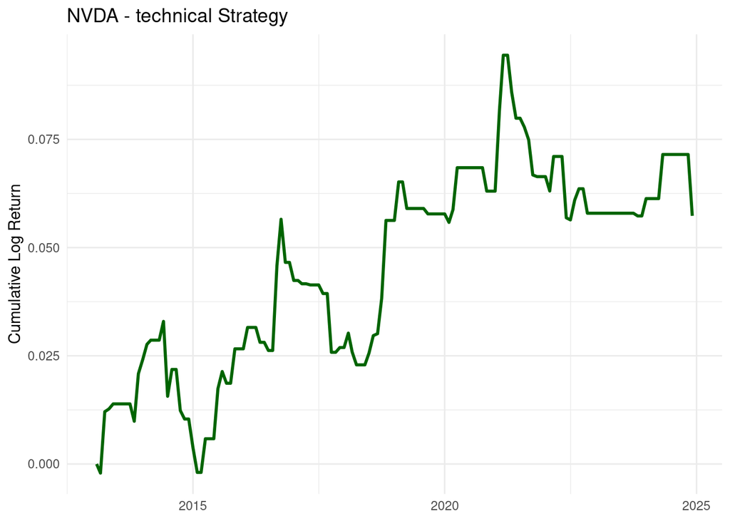

```
##
## === Backtest: NVDA - hybrid ===
## Sharpe Ratio: 0.0046  | Win Rate: 0.1338  | Max Drawdown: 0
```

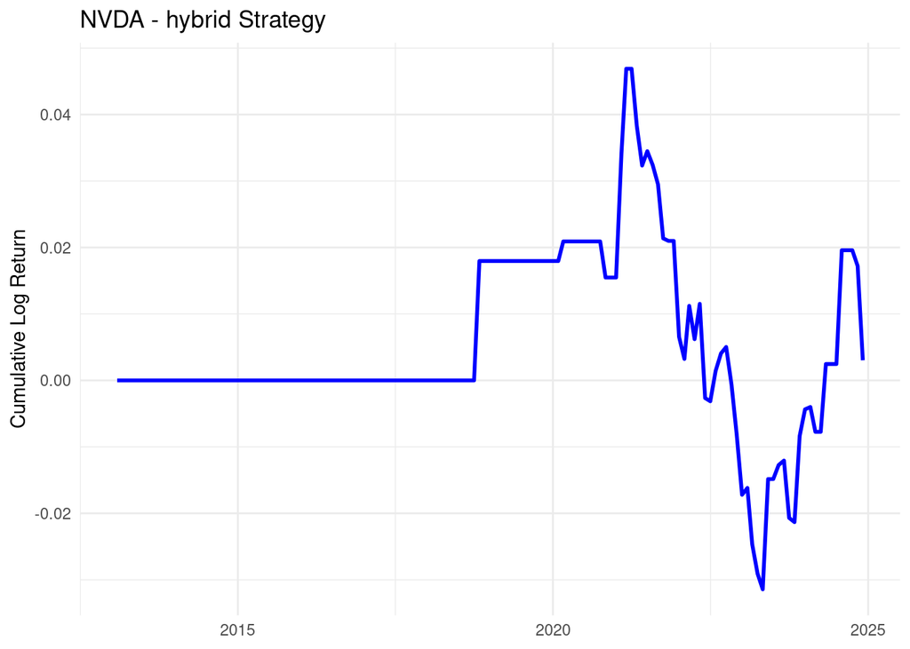

```
##
## === Backtest: SOXL - technical ===
## Sharpe Ratio: -0.0601  | Win Rate: 0.162  | Max Drawdown: 0
```

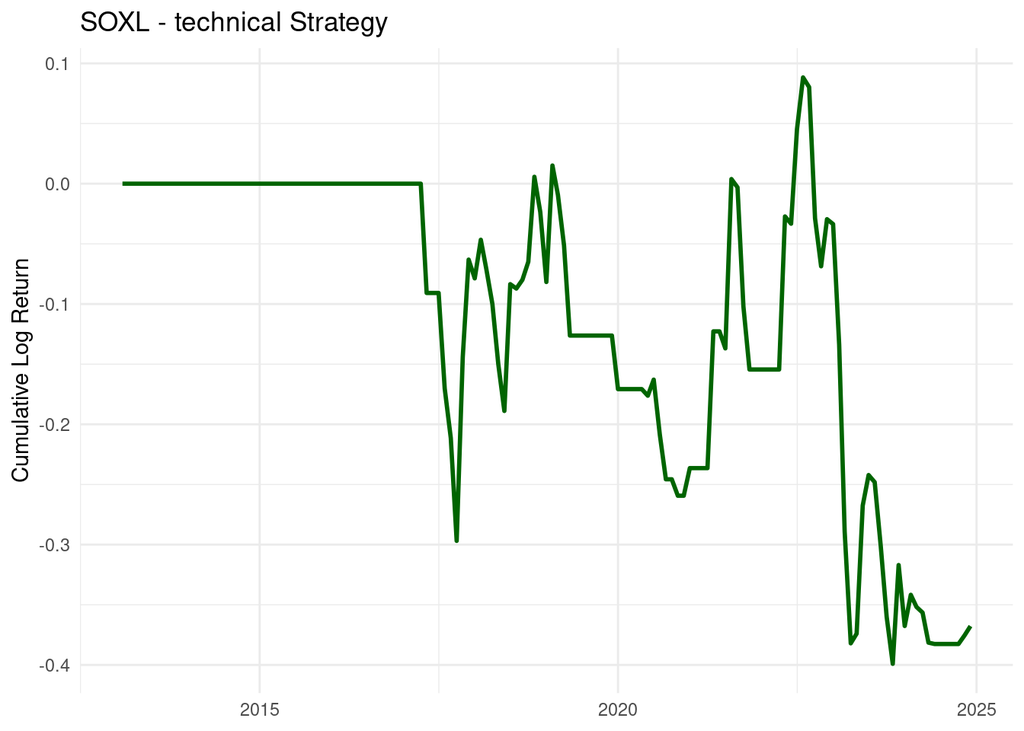

```
##
## === Backtest: SOXL - hybrid ===
## Sharpe Ratio: 0.041  | Win Rate: 0.1268  | Max Drawdown: 0
```

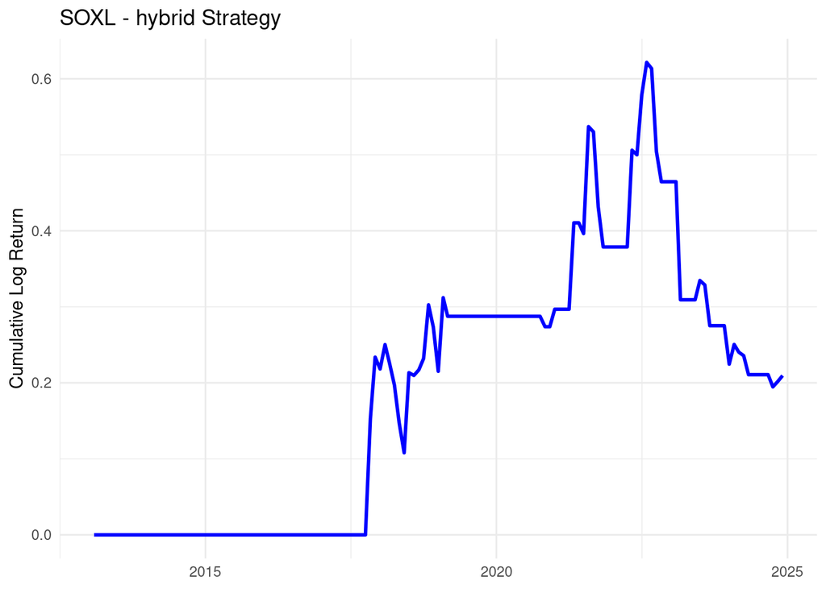

```
##
## === Backtest: XOM - technical ===
## Sharpe Ratio: 0.039  | Win Rate: 0.2606  | Max Drawdown: 0
```

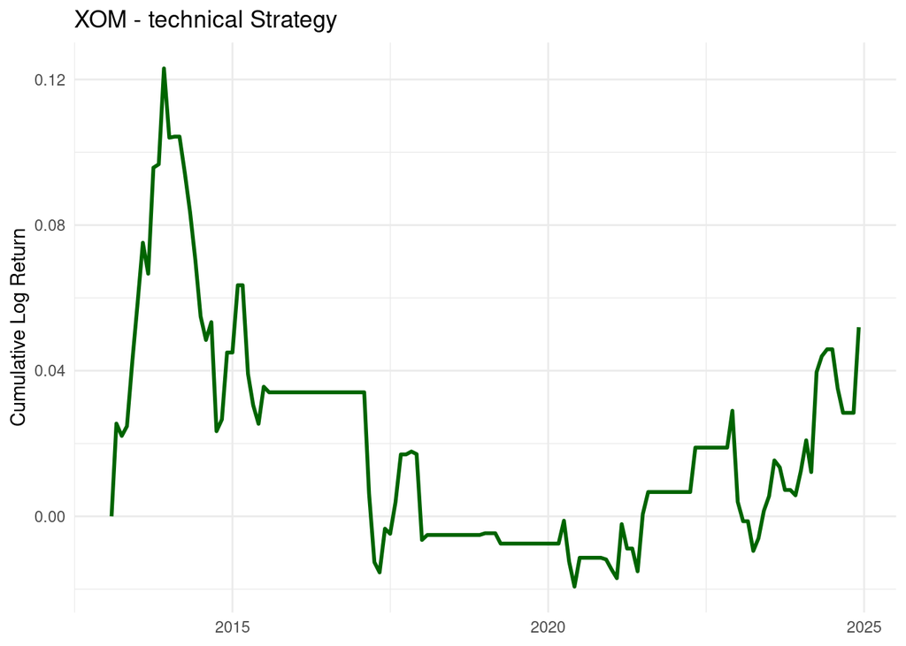

```
##
## === Backtest: XOM - hybrid ===
## Sharpe Ratio: -0.0014  | Win Rate: 0.1549  | Max Drawdown: 0
```

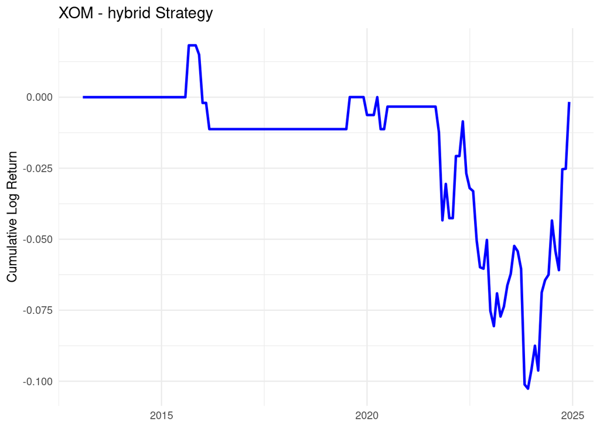

```
##
## === Backtest: CLS.TO - technical ===
## Sharpe Ratio: -0.0076  | Win Rate: 0.1831  | Max Drawdown: 0
```

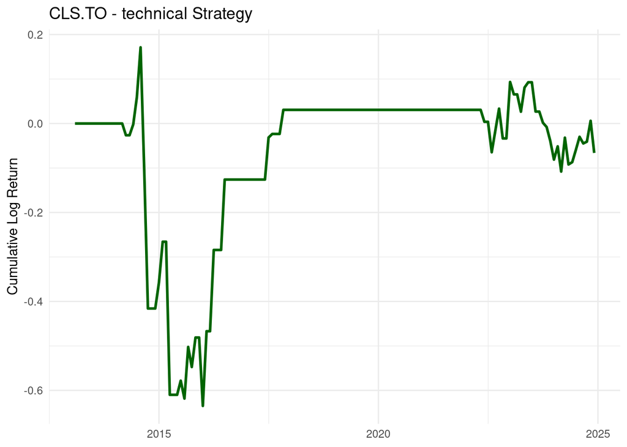

```
##
## === Backtest: CLS.TO - hybrid ===
## Sharpe Ratio: 0.1207  | Win Rate: 0.2042  | Max Drawdown: 0
```

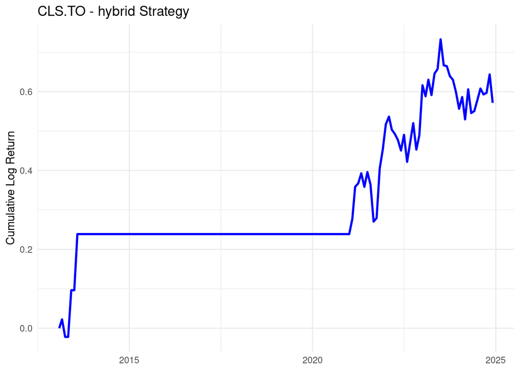

```r
library(PerformanceAnalytics)
library(xts)
library(ggplot2)

# Common parameters
threshold <- 0.6
symbols <- c("NVDA", "SOXL", "XOM", "CLS.TO")

# Define strategy backtest function
backtest_strategy <- function(sym, strategy_df, strategy_type) {
  f_col <- paste0(ifelse(strategy_type == "technical", "f_tech_", "f_hyb_"), sym)
  ret_col <- paste0("logret_", sym)

  df_test <- merge(strategy_df[, c("Date", f_col)],
                   logret_df[, c("Date", ret_col)],
                   by = "Date") |> arrange(Date)

  df_test$signal <- ifelse(df_test[[f_col]] > threshold, 1,
                            ifelse(df_test[[f_col]] < (1 - threshold), -1, 0))
  df_test$position <- dplyr::lag(df_test$signal, 1, default = 0)

  df_test$strat_ret <- df_test$position * df_test[[ret_col]]
  df_test$cum_ret <- cumsum(ifelse(is.na(df_test$strat_ret), 0, df_test$strat_ret))

  # Performance metrics
  mu <- mean(df_test$strat_ret, na.rm = TRUE)
  sd_ <- sd(df_test$strat_ret, na.rm = TRUE)
  sharpe_ <- ifelse(sd_ == 0, NA, mu / sd_)

  wins <- sum(df_test$strat_ret > 0, na.rm = TRUE)
  trades <- sum(!is.na(df_test$strat_ret))
  winrate_ <- ifelse(trades == 0, NA, wins / trades)

  equity_curve <- exp(df_test$cum_ret)
  equity_xts <- xts(equity_curve, order.by = as.Date(df_test$Date))
  max_dd <- PerformanceAnalytics::maxDrawdown(equity_xts)

  # Print result
  cat("\n=== Backtest:", sym, "-", strategy_type, "===\n")
  cat("Sharpe Ratio:", round(sharpe_, 4),
      " | Win Rate:", round(winrate_, 4),
      " | Max Drawdown:", round(max_dd, 4), "\n")

  # Plot cumulative log return
  ggplot(df_test, aes(x = Date, y = cum_ret)) +
    geom_line(color = ifelse(strategy_type == "technical", "darkgreen", "blue"), linewidth = 1) +
    labs(title = paste0(sym, " - ", strategy_type, " Strategy"),
         x = NULL, y = "Cumulative Log Return") +
    theme_minimal()
}

# Run the loop for all symbols
for (sym in symbols) {
  print(backtest_strategy(sym, f_technical_df, "technical"))
  print(backtest_strategy(sym, f_hybrid_df, "hybrid"))
}
```

Anyway, we can optimize based on grid search. for threshold and wieghts based on alpha, which is considering both winrate and sharp ratio.

```r
optimize_threshold <- function(f_signal_df, logret_df, sym, strategy = "hybrid",
                               threshold_grid = seq(0.4, 0.7, by = 0.01), alpha = 0.7) {
  library(xts)
  library(PerformanceAnalytics)

  f_col <- if (strategy == "hybrid") paste0("f_hyb_", sym) else paste0("f_tech_", sym)
  ret_col <- paste0("logret_", sym)

  df <- merge(f_signal_df[, c("Date", f_col)],
              logret_df[, c("Date", ret_col)],
              by = "Date") |> arrange(Date)

  best_score <- -Inf
  best_thresh <- NA
  results <- data.frame()

  for (thresh in threshold_grid) {
    df$signal <- ifelse(df[[f_col]] > thresh, 1,
                        ifelse(df[[f_col]] < (1 - thresh), -1, 0))
    df$position <- dplyr::lag(df$signal, 1, default = 0)
    df$strat_ret <- df$position * df[[ret_col]]
    mu <- mean(df$strat_ret, na.rm = TRUE)
    sd_ <- sd(df$strat_ret, na.rm = TRUE)
    sharpe <- ifelse(sd_ == 0, NA, mu / sd_)
    wins <- sum(df$strat_ret > 0, na.rm = TRUE)
    trades <- sum(!is.na(df$strat_ret))
    winrate <- ifelse(trades == 0, NA, wins / trades)
    score <- 0.7 * sharpe + 0.3 * winrate

    results <- rbind(results, data.frame(threshold = thresh, Sharpe = sharpe,
                                         WinRate = winrate, Score = score))
    if (!is.na(score) && score > best_score) {
      best_score <- score
      best_thresh <- thresh
    }
  }

  list(best_threshold = best_thresh,
       best_score = best_score,
       full_results = results)
}
```

```
##
##  Optimizing NVDA ...
##  NVDA : Best Result
##    Symbol  w1  w2 threshold     Score    Sharpe   WinRate
## 31   NVDA 0.2 0.8      0.68 0.2211374 0.1861319 0.3028169
```

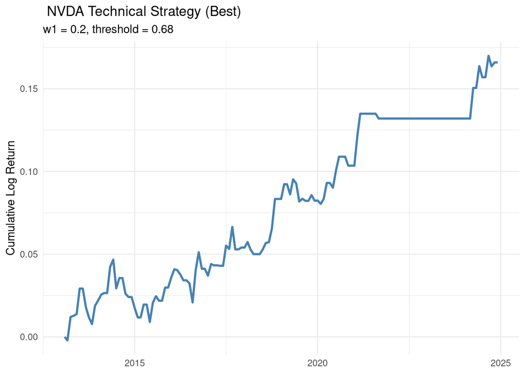

```
##
##  Optimizing SOXL ...
##  SOXL : Best Result
##    Symbol  w1  w2 threshold     Score    Sharpe   WinRate
## 36   SOXL 0.3 0.7      0.46 0.2034184 0.0853663 0.4788732
```

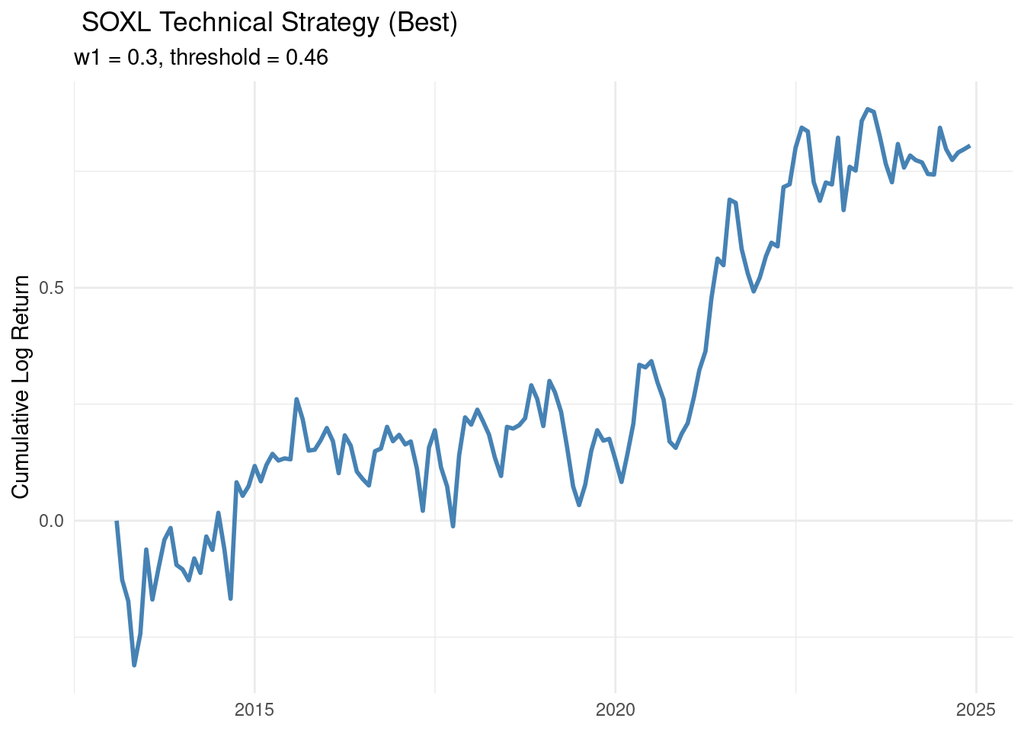

```
##
##  Optimizing XOM ...
##  XOM : Best Result
##    Symbol  w1  w2 threshold     Score    Sharpe   WinRate
## 18    XOM 0.2 0.8      0.42 0.2933952 0.1625968 0.5985915
```

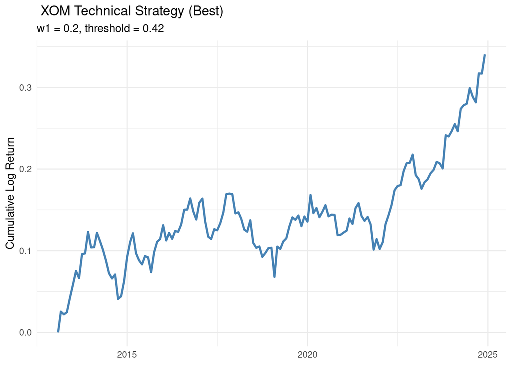

```
##
##  Optimizing CLS.TO ...
##  CLS.TO : Best Result
##     Symbol  w1  w2 threshold     Score   Sharpe   WinRate
## 130 CLS.TO 0.9 0.1      0.42 0.2720905 0.144234 0.5704225
```

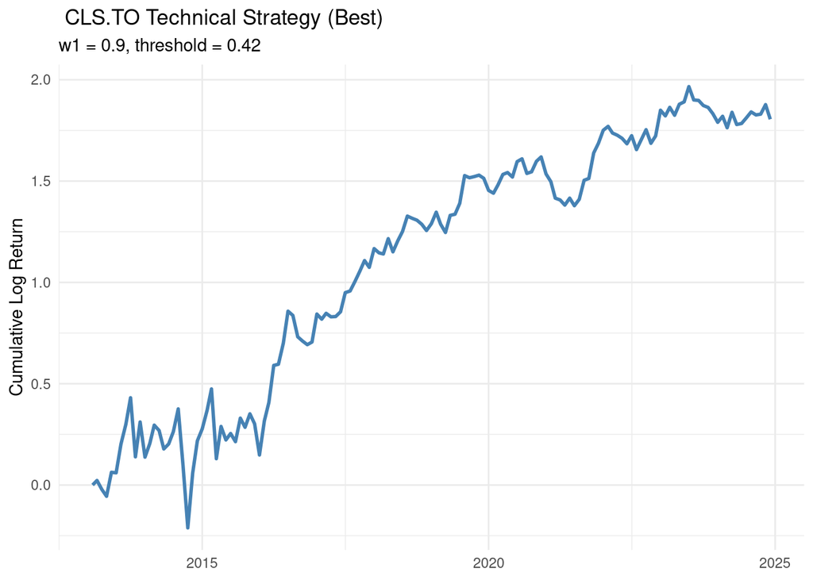

```r
library(ggplot2)
library(xts)
library(PerformanceAnalytics)

symbols <- c("NVDA", "SOXL", "XOM", "CLS.TO")
threshold_grid <- seq(0.4, 0.7, by = 0.02)
w1_grid <- seq(0.1, 0.9, by = 0.1)

global_results <- list()

for (sym in symbols) {
  cat("\n Optimizing", sym, "...\n")
  results <- data.frame()

  for (w1 in w1_grid) {
    w2 <- 1 - w1

    f_tech_test <- p_ma_3_12_sync
    f_tech_test[symbols] <- w1 * p_ma_3_12_sync[symbols] + w2 * p_risk_sync[symbols]
    names(f_tech_test)[-1] <- paste0("f_tech_", symbols)

    for (threshold in threshold_grid) {
      res <- optimize_threshold(
        f_signal_df = f_tech_test,
        logret_df = logret_df,
        sym = sym,
        strategy = "technical",
        threshold_grid = threshold,
        alpha = 0.7
      )

      results <- rbind(results, data.frame(
        Symbol = sym,
        w1 = w1,
        w2 = w2,
        threshold = threshold,
        Score = res$best_score,
        Sharpe = res$full_results$Sharpe[1],
        WinRate = res$full_results$WinRate[1]
      ))
    }
  }

  global_results[[sym]] <- results

  #  Extract best parameter combination
  best_row <- results[which.max(results$Score), ]
  cat("", sym, ": Best Result\n")
  print(best_row)

  #  Generate signal using best parameters
  w1_best <- best_row$w1
  w2_best <- best_row$w2
  threshold_best <- best_row$threshold

  f_best <- p_ma_3_12_sync
  f_best[symbols] <- w1_best * p_ma_3_12_sync[symbols] + w2_best * p_risk_sync[symbols]
  names(f_best)[-1] <- paste0("f_tech_", symbols)

  #  Log return
  f_col <- paste0("f_tech_", sym)
  ret_col <- paste0("logret_", sym)

  df_plot <- merge(f_best[, c("Date", f_col)],
                   logret_df[, c("Date", ret_col)], by = "Date") |>
    arrange(Date)

  df_plot$signal <- ifelse(df_plot[[f_col]] > threshold_best, 1,
                            ifelse(df_plot[[f_col]] < (1 - threshold_best), -1, 0))
  df_plot$position <- dplyr::lag(df_plot$signal, 1, default = 0)
  df_plot$strat_ret <- df_plot$position * df_plot[[ret_col]]
  df_plot$cum_ret <- cumsum(ifelse(is.na(df_plot$strat_ret), 0, df_plot$strat_ret))

  #  Plot cumulative return graph
  p <- ggplot(df_plot, aes(x = Date, y = cum_ret)) +
    geom_line(color = "steelblue", linewidth = 1) +
    labs(title = paste0(" ", sym, " Technical Strategy (Best)"),
         subtitle = paste0("w1 = ", w1_best, ", threshold = ", threshold_best),
         x = NULL, y = "Cumulative Log Return") +
    theme_minimal()

  print(p)
}
```

```
##
##  Optimizing Hybrid Strategy for NVDA ...
##  NVDA : Best Hybrid Result
##    Symbol  w1  w2 alpha threshold     Score    Sharpe   WinRate
## 95   NVDA 0.1 0.9   0.9      0.68 0.2121874 0.1612738 0.3309859
```

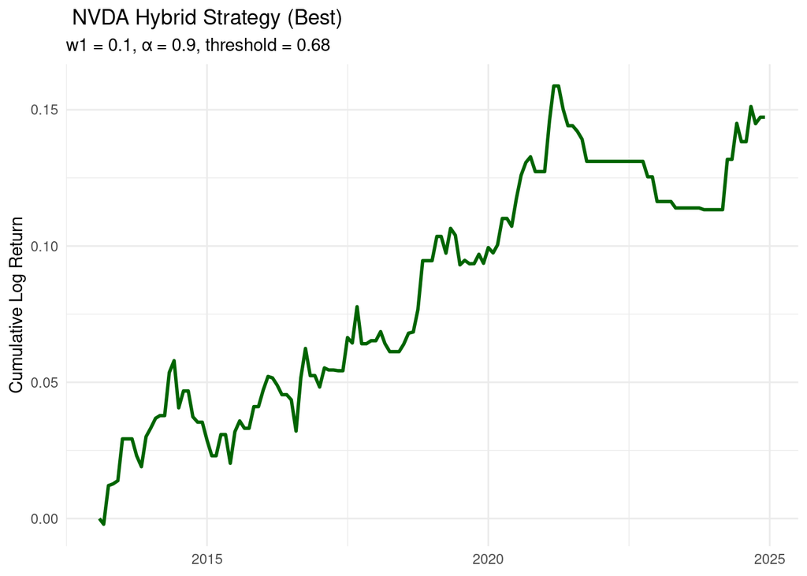

```
##
##  Optimizing Hybrid Strategy for SOXL ...
##  SOXL : Best Hybrid Result
##     Symbol  w1  w2 alpha threshold     Score    Sharpe   WinRate
## 117   SOXL 0.2 0.8   0.5      0.48 0.2225263 0.1066271 0.4929577
```

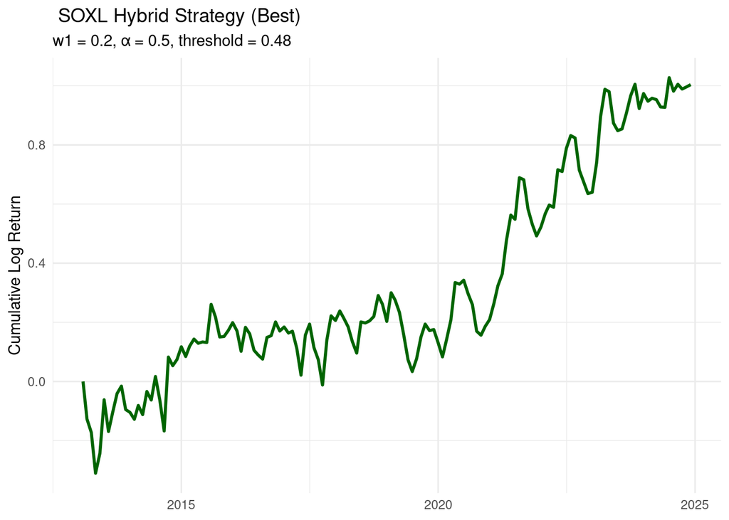

```
##
##  Optimizing Hybrid Strategy for XOM ...
##  XOM : Best Hybrid Result
##    Symbol  w1  w2 alpha threshold     Score    Sharpe   WinRate
## 83    XOM 0.1 0.9   0.9      0.44 0.2799889 0.1464631 0.5915493
```

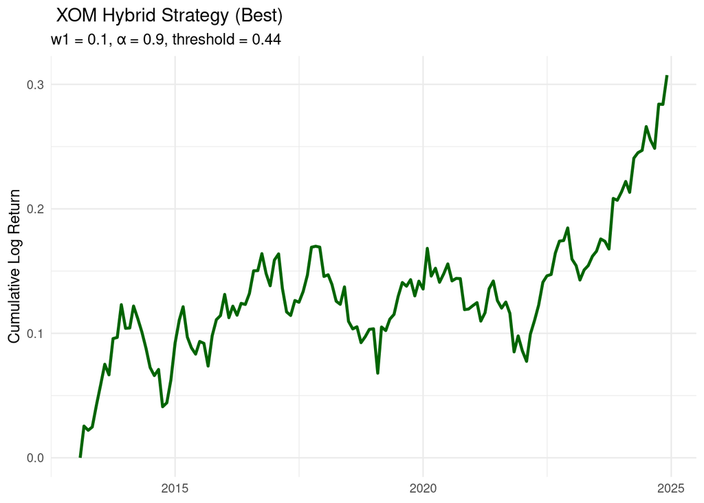

```
##
##  Optimizing Hybrid Strategy for CLS.TO ...
##  CLS.TO : Best Hybrid Result
##     Symbol  w1  w2 alpha threshold   Score    Sharpe   WinRate
## 834 CLS.TO 0.9 0.1   0.8      0.42 0.28223 0.1496646 0.5915493
```

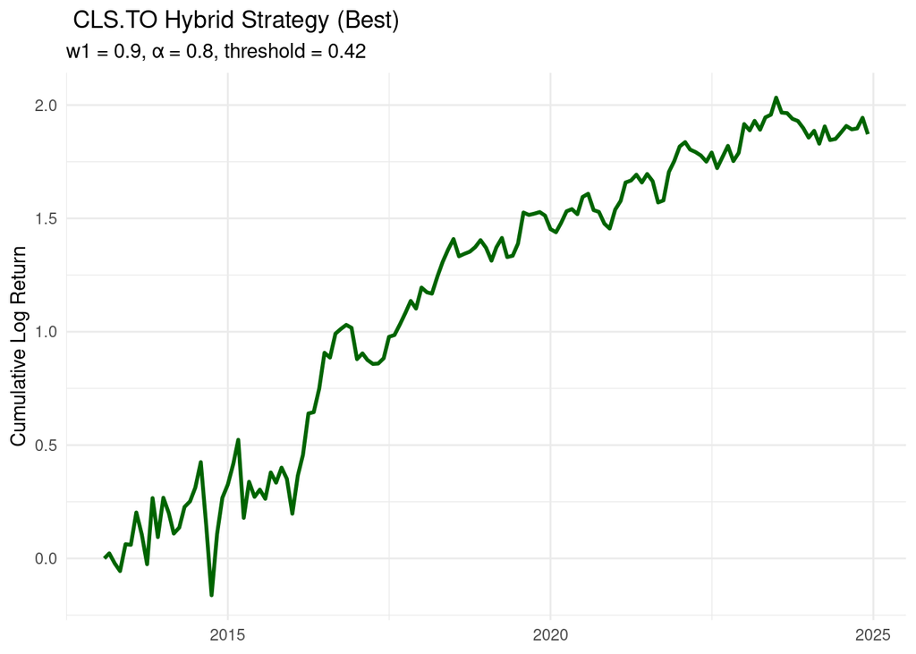

```r
library(ggplot2)
library(xts)
library(PerformanceAnalytics)

symbols <- c("NVDA", "SOXL", "XOM", "CLS.TO")

threshold_grid <- seq(0.4, 0.7, by = 0.02)
w1_grid <- seq(0.1, 0.9, by = 0.1)      # P_MA
alpha_grid <- seq(0.4, 0.9, by = 0.1)   # Hybrid

global_results_hyb <- list()

for (sym in symbols) {
  cat("\n Optimizing Hybrid Strategy for", sym, "...\n")
  results <- data.frame()

  for (w1 in w1_grid) {
    w2 <- 1 - w1

    # f_technical
    f_tech_temp <- p_ma_3_12_sync
    f_tech_temp[symbols] <- w1 * p_ma_3_12_sync[symbols] + w2 * p_risk_sync[symbols]
    names(f_tech_temp)[-1] <- paste0("f_tech_", symbols)

    for (alpha in alpha_grid) {
      # f_hybrid
      f_hyb_temp <- f_tech_temp[, "Date", drop=FALSE]
      for (s in symbols) {
        f_hyb_temp[[paste0("f_hyb_", s)]] <-
          alpha * f_tech_temp[[paste0("f_tech_", s)]] +
          (1 - alpha) * p_econ_sync[[s]]
      }

      for (threshold in threshold_grid) {
        res <- optimize_threshold(
          f_signal_df = f_hyb_temp,
          logret_df = logret_df,
          sym = sym,
          strategy = "hybrid",
          threshold_grid = threshold,
          alpha = alpha
        )

        results <- rbind(results, data.frame(
          Symbol = sym,
          w1 = w1,
          w2 = w2,
          alpha = alpha,
          threshold = threshold,
          Score = res$best_score,
          Sharpe = res$full_results$Sharpe[1],
          WinRate = res$full_results$WinRate[1]
        ))
      }
    }
  }

  global_results_hyb[[sym]] <- results

  #  Extract and print optimal results
  best_row <- results[which.max(results$Score), ]
  cat("", sym, ": Best Hybrid Result\n")
  print(best_row)

  #   f_technical + f_hybrid
  w1_best <- best_row$w1
  w2_best <- best_row$w2
  alpha_best <- best_row$alpha
  threshold_best <- best_row$threshold

  f_tech_best <- p_ma_3_12_sync
  f_tech_best[symbols] <- w1_best * p_ma_3_12_sync[symbols] + w2_best * p_risk_sync[symbols]
  names(f_tech_best)[-1] <- paste0("f_tech_", symbols)

  f_hyb_best <- f_tech_best[, "Date", drop=FALSE]
  for (s in symbols) {
    f_hyb_best[[paste0("f_hyb_", s)]] <-
      alpha_best * f_tech_best[[paste0("f_tech_", s)]] +
      (1 - alpha_best) * p_econ_sync[[s]]
  }

  f_col <- paste0("f_hyb_", sym)
  ret_col <- paste0("logret_", sym)

  df_plot <- merge(f_hyb_best[, c("Date", f_col)],
                   logret_df[, c("Date", ret_col)], by = "Date") |>
    arrange(Date)

  df_plot$signal <- ifelse(df_plot[[f_col]] > threshold_best, 1,
                            ifelse(df_plot[[f_col]] < (1 - threshold_best), -1, 0))
  df_plot$position <- dplyr::lag(df_plot$signal, 1, default = 0)
  df_plot$strat_ret <- df_plot$position * df_plot[[ret_col]]
  df_plot$cum_ret <- cumsum(ifelse(is.na(df_plot$strat_ret), 0, df_plot$strat_ret))

  #  Visualize cumulative return
  p <- ggplot(df_plot, aes(x = Date, y = cum_ret)) +
    geom_line(color = "darkgreen", linewidth = 1) +
    labs(title = paste0(" ", sym, " Hybrid Strategy (Best)"),
         subtitle = paste0("w1 = ", w1_best,
                           ", α = ", alpha_best,
                           ", threshold = ", threshold_best),
         x = NULL, y = "Cumulative Log Return") +
    theme_minimal()

  print(p)
}
```